# Data Manipulation with R

# The `pipe` operator

As stated in “R for data science” by Hadley Wickham and Garrett Grolemund, **pipes are powerful tools for clearly expressing a sequence of multiple operations**. The pipe operator (`%>%`) allows us to pipe the output from one function to the input of another function. The idea of piping is to read the functions from left to right. It is particularly useful with nested functions (reading from the inside to the outside) or with multiple operations.

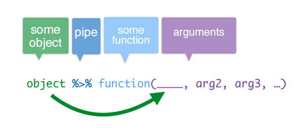

Source: www.datacamp.com

Pipes can work with nearly any functions (`tidyverse` and not-`tidyverse` functions), let us see an example.

Let us consider `bank` data set, included in `qdata` package, which contains information about a direct marketing campaigns of a Portuguese banking institution based on phone calls.

```r
require(qdata)
data(bank)
```

Suppose you want to visualize the first rows of `bank` dataframe, by using `head()` function.

Usually you write:

```r
head(bank)
```

```
## # A tibble: 6 x 20
##      id   age          job marital education default balance housing   loan contact   day  month  year
##   <int> <int>       <fctr>  <fctr>    <fctr>  <fctr>   <int>  <fctr> <fctr>  <fctr> <int> <fctr> <int>
## 1     1    58   management married  tertiary      no    2143     yes     no unknown     5    may  2008
## 2     2    44   technician  single secondary      no      29     yes     no unknown     5    may  2008
## 3     3    33 entrepreneur married secondary      no       2     yes    yes unknown     5    may  2008
## 4     4    47  blue-collar married   unknown      no    1506     yes     no unknown     5    may  2008
## 5     5    33      unknown  single   unknown      no       1      no     no unknown     5    may  2008
## 6     6    35   management married  tertiary      no     231     yes     no unknown     5    may  2008
## # ... with 7 more variables: date <dttm>, duration <int>, campaign <int>, pdays <int>, previous <int>,
## #   poutcome <fctr>, y <fctr>
```

By using `%>%`, the code becomes:

```r
bank %>% head()
```

```
## # A tibble: 6 x 20
##      id   age          job marital education default balance housing   loan contact   day  month  year
##   <int> <int>       <fctr>  <fctr>    <fctr>  <fctr>   <int>  <fctr> <fctr>  <fctr> <int> <fctr> <int>
## 1     1    58   management married  tertiary      no    2143     yes     no unknown     5    may  2008
## 2     2    44   technician  single secondary      no      29     yes     no unknown     5    may  2008
## 3     3    33 entrepreneur married secondary      no       2     yes    yes unknown     5    may  2008
## 4     4    47  blue-collar married   unknown      no    1506     yes     no unknown     5    may  2008
## 5     5    33      unknown  single   unknown      no       1      no     no unknown     5    may  2008
## 6     6    35   management married  tertiary      no     231     yes     no unknown     5    may  2008
## # ... with 7 more variables: date <dttm>, duration <int>, campaign <int>, pdays <int>, previous <int>,
## #   poutcome <fctr>, y <fctr>
```

Pipe takes the argument on the left (`bank`) and passes it to the function on the right (`head()`). So you don’t need to write the first argument of the function.

Other arguments of the function must be added to the function itself, as usually done. By default `head()` prints the first 6 rows of the dataframe. Suppose you want to print 10 rows, by setting `n` argument to 10:

```r
bank %>% head(n=10)
```

```
## # A tibble: 10 x 20
##       id   age          job  marital education default balance housing   loan contact   day  month  year
##    <int> <int>       <fctr>   <fctr>    <fctr>  <fctr>   <int>  <fctr> <fctr>  <fctr> <int> <fctr> <int>
##  1     1    58   management  married  tertiary      no    2143     yes     no unknown     5    may  2008
##  2     2    44   technician   single secondary      no      29     yes     no unknown     5    may  2008
##  3     3    33 entrepreneur  married secondary      no       2     yes    yes unknown     5    may  2008
##  4     4    47  blue-collar  married   unknown      no    1506     yes     no unknown     5    may  2008
##  5     5    33      unknown   single   unknown      no       1      no     no unknown     5    may  2008
##  6     6    35   management  married  tertiary      no     231     yes     no unknown     5    may  2008
##  7     7    28   management   single  tertiary      no     447     yes    yes unknown     5    may  2008
##  8     8    42 entrepreneur divorced  tertiary     yes       2     yes     no unknown     5    may  2008
##  9     9    58      retired  married   primary      no     121     yes     no unknown     5    may  2008
## 10    10    43   technician   single secondary      no     593     yes     no unknown     5    may  2008
## # ... with 7 more variables: date <dttm>, duration <int>, campaign <int>, pdays <int>, previous <int>,
## #   poutcome <fctr>, y <fctr>
```